# Legislação Ambiental, APP, PRAD e Gestão

Análise Ambiental · Aula 15.1

Prof. Dr. Luiz Diego Vidal Santos

## Abertura Visão Geral da Aula

**01 · Código Florestal (Lei 12.651/2012):** todas as faixas de **APP** (Art. 4º) e **Reserva Legal** (Art. 12).

**02 · Regularização Rural:** Áreas Consolidadas (Art. 61-A), Cadastro Ambiental Rural (**CAR**) e **PRA**.

**03 · SNUC (Lei 9.985/2000):** as 12 categorias entre Proteção Integral e Uso Sustentável.

**04 · PRAD (IN IBAMA 14/2024):** estrutura técnica oficial e métodos de restauração florestal.

**05 · PNPSA e Bahia:** Pagamento por Serviços Ambientais (**Lei 14.119/2021**) e governança (INEMA/CEPRAM).

**06 · Responsabilidade:** Tríplice Responsabilidade Ambiental (CF/88 Art. 225, § 3º e Lei 9.605/1998).

Objetivo da Aula Parâmetros normativos e perícia ambiental

Dominar os parâmetros métricos, percentuais e normativos da legislação ambiental brasileira e baiana (**Lei 12.651/2012, Lei 9.985/2000, Lei 14.119/2021, Lei 9.605/1998 e IN IBAMA 14/2024**) indispensáveis para laudos, CAR, PRAD, EIA-RIMA e concursos públicos.

Lei 12.651/2012 SNUC 9.985/2000 IN IBAMA 14/2024 PNPSA 14.119/2021

# Código Florestal: APPs e Reserva Legal

## Lei 12.651/12 Visão Integrada: Licenciamento e Faixas de APP

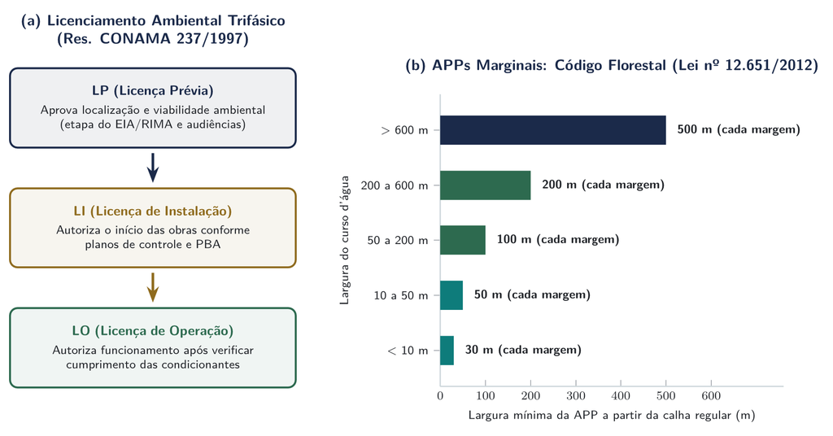

Síntese normativa do licenciamento ambiental trifásico (CONAMA 237/1997) e das faixas marginais de APP no Código Florestal (Lei nº 12.651/2012).

Licenciamento Trifásico (CONAMA 237/1997) e APPs Marginais (Lei nº 12.651/2012) Articulação entre controle preventivo de empreendimentos (LP, LI, LO) e faixas de proteção hídrica

## Lei 12.651/12 APPs Hídricas (Margens de Rios, Lagos e Nascentes)

Faixas marginais de **qualquer curso d’água natural perene e intermitente** (excluídos os efêmeros), medidas desde a **borda da calha do leito regular** (Art. 4º):

| Largura do Curso d’Água | Largura Mínima de APP (cada margem) |
| --- | --- |
| **Menos de $10\text{ m}$** | **$30\text{ metros}$** |
| **De $10\text{ a }50\text{ m}$** | **$50\text{ metros}$** |
| **De $50\text{ a }200\text{ m}$** | **$100\text{ metros}$** |
| **De $200\text{ a }600\text{ m}$** | **$200\text{ metros}$** |
| **Superior a $600\text{ m}$** | **$500\text{ metros}$** |

Demais APPs hídricas Nascentes, lagos e veredas

- **Nascentes e olhos d’água perenes**: raio mínimo de **$50\text{ metros}$** (qualquer situação topográfica).
- **Lagos e lagoas naturais**:
  - **Zona rural**: **$100\text{ m}$** (ou **$50\text{ m}$** para corpo d’água com até $20\text{ ha}$ de superfície);
  - **Zona urbana**: **$30\text{ m}$**.
- **Veredas**: faixa marginal mínima de **$50\text{ m}$** a partir do espaço permanentemente brejoso e encharcado.

## Lei 12.651/12 APPs Geomorfológicas e Ecológicas (Art. 4º, V a XI)

Relevo e altitude Encostas, topos e chapadas

1. **Encostas ou partes destas**: declividade superior a **$45^\circ$** ($100\%$ na linha de maior declive).
2. **Topos de morros, montes, montanhas e serras**: altura mínima de **$100\text{ m}$** (base/sela mais próxima) **E** inclinação média maior que **$25^\circ$ ($46{,}6\%$)**, no **terço superior** do relevo.
3. **Bordas dos tabuleiros ou chapadas**: até a linha de ruptura do relevo, faixa mínima de **$100\text{ m}$** em projeções horizontais.

Ecossistemas críticos Altitude e zona costeira

4. **Altitude superior a $1.800\text{ m}$**: qualquer que seja a vegetação.
5. **Restingas** (como fixadoras de dunas ou estabilizadoras de mangues) e **Manguezais** (em toda a sua extensão).

**Regra de Intervenção em APP (Art. 8º):** a vegetação em APP deve ser mantida; a intervenção ou supressão **só é admitida nos casos excepcionais de Utilidade Pública, Interesse Social ou Baixo Impacto Ambiental** devidamente licenciados.

## Lei 12.651/12 Reserva Legal (RL): Percentuais e Regime de Uso

Art. 3º, III e Art. 12 Conceito e Percentuais Mínimos

Área no interior do imóvel rural para assegurar **uso econômico sustentável**, conservação ecológica e biodiversidade:

- **Amazônia Legal**: **$80\%$** (floresta), **$35\%$** (cerrado) e **$20\%$** (campos gerais).
- **Demais Regiões do País (toda a Bahia — Caatinga, Mata Atlântica e Cerrado baiano)**: **$20\%$** da área total do imóvel!

Distinção jurídica fundamental APP × Reserva Legal

- A **APP** é intocável como regra geral (preservação rígida de funções hídricas e geomorfológicas).
- A **Reserva Legal** admite exploração econômica mediante **Manejo Florestal Sustentável** aprovado pelo órgão ambiental (ou coleta sem propósito comercial).

## Lei 12.651/12 CAR, PRA e a “Escadinha” do Art. 61-A

Art. 29 e Art. 3º, IV CAR e Área Rural Consolidada

- **CAR (Cadastro Ambiental Rural)**: registro público eletrônico nacional obrigatório para todos os imóveis rurais, integrando APPs, RL, florestas e áreas consolidadas.
- **Área Rural Consolidada**: ocupação antrópica preexistente a **22 de julho de 2008**.

Art. 61-A · Módulos Fiscais (MF) Recomposição escalonada de APP hídrica

- Até **$1\text{ MF}$**: recomposição obrigatória de **$5\text{ m}$**;
- $> 1\text{ até }2\text{ MF}$: recomposição de **$8\text{ m}$**;
- $> 2\text{ até }4\text{ MF}$: recomposição de **$15\text{ m}$**;
- $> 4\text{ MF}$: de **$20\text{ a }100\text{ m}$** conforme o PRA;
- Nascentes consolidadas: raio mínimo de **$15\text{ m}$**.

## Lei 12.651/12 Síntese Visual: Faixas de APP e Fluxo de Regularização

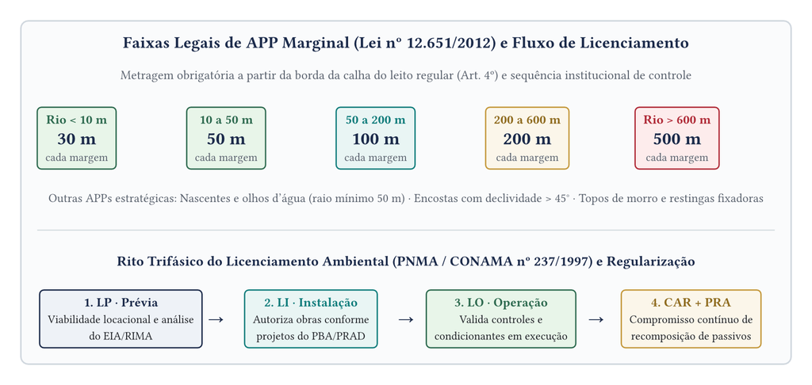

Quadro-síntese das faixas marginais de APP (Lei nº 12.651/2012) e fluxo do licenciamento trifásico com regularização via CAR + PRA.

Faixas Legais de APP Marginal e Rito de Regularização (LP · LI · LO · CAR + PRA) Metragem a partir da borda da calha regular (Art. 4º) articulada ao controle e recomposição de passivos

# Sistema Nacional de Unidades de Conservação (SNUC)

## SNUC O que é o SNUC e por que Dividir em Dois Grupos?

Lei nº 9.985/2000 Sistema Nacional de Unidades de Conservação

Unificou critérios para criar, implantar e gerir áreas protegidas nas esferas federal, estadual e municipal, exigindo **plano de manejo** e **zona de amortecimento**.

Grau de intervenção permitido Proteção Integral (5) vs. Uso Sustentável (7)

- **Proteção Integral (5 categorias):** preservar a natureza, admitindo apenas **uso indireto** (pesquisa, educação ambiental e visitação controlada).
- **Uso Sustentável (7 categorias):** compatibilizar conservação com **uso direto** e manejado por populações tradicionais ou proprietários.

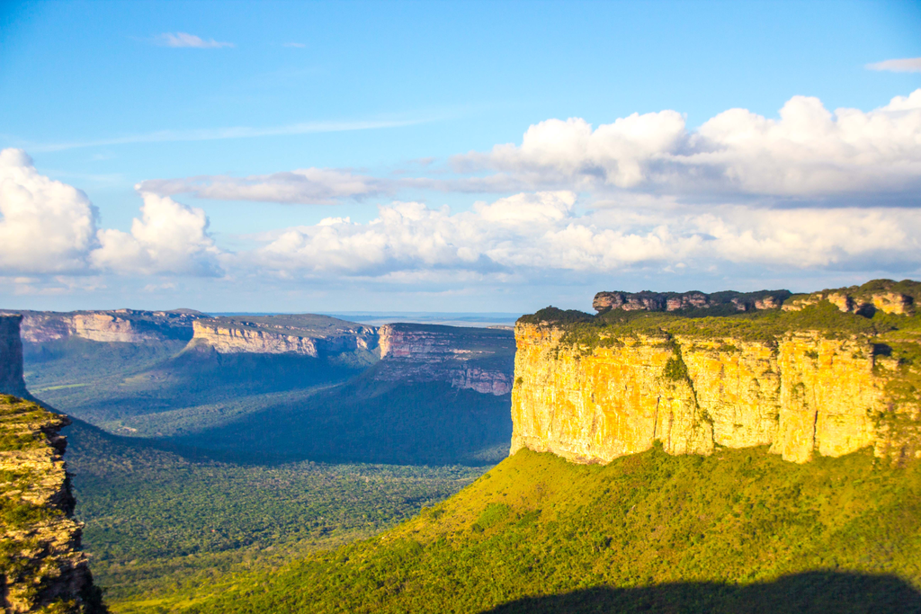

Parque Nacional da Chapada Diamantina (BA), exemplo de Unidade de Conservação de Proteção Integral na Bahia. Fonte: Wikimedia Commons.

Parque Nacional da Chapada Diamantina (BA) Unidade de Conservação de Proteção Integral na Bahia · Fonte: Wikimedia Commons

## SNUC SNUC: cinco categorias de Proteção Integral

| Categoria | Finalidade e regime geral |
| --- | --- |
| **Estação Ecológica** | Preservação e pesquisa; visitação educacional conforme regras |
| **Reserva Biológica** | Preservação integral da biota e atributos naturais |
| **Parque** | Preservação, pesquisa, educação e recreação compatíveis |
| **Monumento Natural** | Sítios naturais raros, singulares ou de beleza cênica |
| **Refúgio de Vida Silvestre** | Ambientes necessários à existência e reprodução de espécies |

Admite-se uso indireto, com as exceções previstas na Lei 9.985/2000. Monumento Natural e Refúgio podem incluir áreas particulares compatíveis com seus objetivos.

## SNUC SNUC: sete categorias de Uso Sustentável

| Categoria | Finalidade e regime geral |
| --- | --- |
| **APA** | Disciplinar ocupação e uso sustentável em área geralmente extensa |
| **ARIE** | Manter ecossistemas de importância regional ou local |
| **Floresta Nacional** | Uso múltiplo sustentável dos recursos florestais e pesquisa |
| **Reserva Extrativista** | Proteger modos de vida e uso sustentável por populações tradicionais |
| **Reserva de Fauna** | Estudos de manejo econômico sustentável de fauna nativa |
| **Reserva de Desenvolvimento Sustentável** | Preservação e reprodução dos modos de vida tradicionais |
| **RPPN** | Conservação em área privada gravada com perpetuidade |

O grupo não autoriza qualquer uso. Consultar objetivos, domínio, zoneamento e plano de manejo de cada categoria.

## SNUC Conceitos Territoriais do SNUC (Art. 2º e Art. 25)

Zoneamento e normas Plano de Manejo

Documento técnico que, com fundamento nos objetivos gerais da UC, estabelece seu **zoneamento** e as normas de uso da área (deve ser elaborado no prazo de **5 anos** a partir da criação da UC).

Pegadinha Clássica de Concurso! Zona de Amortecimento (ZA — Art. 2º, XVIII e Art. 25)

Entorno da UC onde atividades humanas seguem normas específicas para minimizar impactos negativos. Pelo **Art. 25 da Lei 9.985/2000**, todas as UCs devem ter ZA, **EXCETO APA e RPPN**!

## SNUC Conectividade na Paisagem Regional

Art. 2º, XIX Corredores Ecológicos

Porções de ecossistemas naturais ou seminaturais ligando UCs, que possibilitam o **fluxo de genes e o movimento da biota**, facilitando dispersão e recolonização (mitigando a fragmentação insular — MacArthur & Wilson).

Art. 26 Mosaico de Unidades de Conservação

Conjunto de UCs de categorias diferentes ou não, próximas, justapostas ou sobrepostas, e outras áreas protegidas públicas ou privadas, cuja gestão deve ser **integrada e participativa**.

# PRAD, PNPSA e Responsabilidade Ambiental

## PRAD Roteiro Oficial de um PRAD (IN IBAMA nº 14/2024)

Regulamentado pela **IN IBAMA nº 14/2024**, no âmbito dos procedimentos do Ibama (revogou a IN 04/2011). Para outros órgãos, consultar a norma e o termo de referência aplicáveis:

01 · Responsabilidade Identificação e ART

Dados do imóvel/empreendimento e Responsável Técnico (**ART do Geógrafo**).

02 · Diagnóstico Área degradada e resiliência

Clima, geomorfologia, solo e hidrologia; **fatores de degradação ativos** (fogo, gado, erosão, *Urochloa*/*Leucaena*) e potencial de regeneração.

03 · Estratégia Seleção de métodos

Escolha justificada das técnicas de recuperação ou restauração ecológica.

04 · Execução Manutenção e tratos

Controle de formigas cortadeiras, coroamento, adubação de cobertura e replantio conforme metas.

05 · Auditoria Indicadores de monitoramento

Cobertura de dossel ($\%$), densidade de regenerantes ($\text{ind./ha}$) e riqueza nativa em período e frequência definidos.

06 · Gestão Cronograma e orçamento

Cronograma físico de implantação/manutenção e orçamento financeiro detalhado.

## Restauração Quatro Estratégias de Restauração Florestal

| Estratégia | Quando Aplicar (Potencial de Resiliência) | Técnicas Principais |
| --- | --- | --- |
| **1. Condução da Regeneração Natural (Isolamento)** | **Alta resiliência**: solo conservado, banco de sementes/plântulas ativo e fontes de propágulos avaliadas no local. | Cercamento contra o gado, aceiros contra fogo e controle seletivo de gramíneas exóticas. |
| **2. Regeneração c/ Manejo (Adensamento e Enriquecimento)** | **Média resiliência**: regeneração presente, com falhas espaciais (clareiras) ou baixa diversidade. | Plantio de mudas em clareiras (**adensamento**) e introdução de secundárias tardias/clímax (**enriquecimento**). |
| **3. Técnicas de Nucleação (Reis et al., 2003)** | **Média a baixa resiliência**: busca recriar “ilhas de diversidade” que atraiam dispersores de fauna. | Transposição de *topsoil*, poleiros artificiais para avifauna, transposição de galharia e grupos de Anderson. |
| **4. Plantio em Área Total + Bioengenharia** | **Baixíssima resiliência**: solos decapitados, taludes de mineração, voçorocas ou pastagens sem propágulos. | Descompactação, bioengenharia, semeadura direta (*muvuca*) ou plantio alternando **Recobrimento (Pioneiras)** e **Diversidade (Não Pioneiras)**. |

## PNPSA Política Nacional de Pagamento por Serviços Ambientais (Lei nº 14.119/2021)

Lei nº 14.119/2021 Conceito legal do PSA

Transação de natureza voluntária mediante a qual um **pagador** de serviços ambientais transfere a um **provedor** (ex.: agricultor familiar, comunidade tradicional, proprietário rural que conserva água e solo) recursos financeiros ou outra forma de remuneração.

Art. 5º da PNPSA Modalidades de pagamento

- **Pagamento monetário direto** (ex.: Programa *Produtor de Água* da ANA);
- **Melhorias sociais** a comunidades rurais e urbanas;
- Compensação vinculada a certificado de redução de emissões (**REDD+**);
- **Cota de Reserva Ambiental (CRA — Art. 44 da Lei 12.651/2012)** e títulos verdes (*green bonds*).

## Responsabilidade A Tríplice Responsabilidade Ambiental (CF/88 Art. 225, § 3º)

Um único ato lesivo (ex.: suprimir mata ciliar em APP sem licença e assorear rio) sujeita o infrator (PF ou PJ), de forma **cumulativa e independente**, a **três esferas**:

| Esfera | Natureza Jurídica | Sanção Aplicável |
| --- | --- | --- |
| **1. Civil** *(Lei 6.938/81, Art. 14, § 1º)* | **Responsabilidade Objetiva** (independe de culpa; imprescritível — STF Tema 999) | **Obrigação de reparar integralmente o dano (*in natura* via PRAD)** + indenização pelos danos interinos e morais coletivos. |
| **2. Administrativa** *(Lei 9.605/98, Art. 72 e Dec. 6.514/08)* | Poder de Polícia Ambiental (IBAMA, ICMBio, INEMA-BA) | Advertência, **multa simples ou diária**, apreensão de equipamentos, **embargo de obra/área**, suspensão de venda e restritiva de direitos (crédito rural). |
| **3. Penal (Criminal)** *(Lei 9.605/1998)* | Responsabilidade Subjetiva (admite responsabilização penal da **Pessoa Jurídica** — Art. 3º!) | Penas privativas de liberdade (detenção/reclusão), restritivas de direitos (prestação de serviços/interdição) e multa penal. |

## Lei 12.651/12 APP: faixa geral, situação consolidada e decisão

As faixas do art. 4º e as regras de recomposição de áreas rurais consolidadas do art. 61-A têm objetos diferentes.

**01 · Identificar:** caracterizar curso d’água, nascente ou outra hipótese de APP.

**02 · Verificar:** checar regime hídrico, medidas, data de ocupação e situação do imóvel.

**03 · Conferir:** consultar CAR, PRA e normas aplicáveis ao ente federado.

**04 · Área urbana:** em área urbana consolidada, verificar a **Lei 14.285/2021** e a legislação municipal pertinente.

**05 · Documentar:** registrar o fundamento legal e as limitações da delimitação.

Não reduzir a delimitação a um buffer automático nem autorizar intervenção a partir de uma tabela didática.

## PRAD PRAD: metas, monitoramento e responsabilidade

Coerência ecológica Metas compatíveis com o bioma

O PRAD deve ligar fatores de degradação, métodos, metas, indicadores, manutenção e critérios de conclusão:

- O prazo, a amostragem e as metas precisam ser compatíveis com o ecossistema.
- Restaurar a **Caatinga** não equivale a implantar uma floresta de outra região.

Gestão e atribuição Revisão e responsabilidade técnica

- Medidas corretivas dependem do diagnóstico das falhas observadas.
- Responsabilidade técnica deve corresponder às atribuições efetivas do profissional.
- Fonte oficial: [Ibama: recuperação ambiental e procedimentos do PRAD](https://www.gov.br/ibama/pt-br/assuntos/biodiversidade/recuperacao-ambiental).

# Síntese e Referências

## Síntese Resumo Essencial para Provas e Concursos

01 · APPs Hídricas (Art. 4º) Lei 12.651/2012

Rios: $<10\text{ m} \rightarrow 30\text{ m}$; $10\text{–}50\text{ m} \rightarrow 50\text{ m}$; $50\text{–}200\text{ m} \rightarrow 100\text{ m}$; $200\text{–}600\text{ m} \rightarrow 200\text{ m}$; $>600\text{ m} \rightarrow 500\text{ m}$. Nascentes perenes: raio de $50\text{ m}$.

02 · Reserva Legal na Bahia Art. 12 da Lei 12.651/2012

**$20\%$** em todos os biomas estaduais (Caatinga, Mata Atlântica e Cerrado fora da Amazônia Legal).

03 · SNUC (Lei 9.985/2000) 5 Proteção + 7 Uso Sustentável

PI: ESEC, REBIO, Parque, MONA, REVIS. US: APA, ARIE, FLONA, RESEX, REFAU, RDS, RPPN. **APA e RPPN não possuem Zona de Amortecimento!**

## Referências Referências Bibliográficas

Bibliografia da Aula Legislação federal e literatura técnica

- BRASIL. **Lei nº 9.605, de 12 de fevereiro de 1998** (Lei de Crimes Ambientais).
- BRASIL. **Lei nº 9.985, de 18 de julho de 2000** (Sistema Nacional de Unidades de Conservação da Natureza — SNUC).
- BRASIL. **Lei nº 12.651, de 25 de maio de 2012** (Dispõe sobre a proteção da vegetação nativa — Código Florestal).
- BRASIL. **Lei nº 14.119, de 13 de janeiro de 2021** (Política Nacional de Pagamento por Serviços Ambientais — PNPSA).
- IBAMA. **Instrução Normativa nº 14, de 2024** (Procedimentos para elaboração, execução e monitoramento de projetos de recuperação de áreas degradadas ou alteradas — PRAD).
- REIS, A. et al. Restauração de áreas degradadas: a nucleação como base para incrementar os processos sucessionais. **Natureza & Conservação**, v. 1, n. 1, p. 28–36, 2003.